# Estimation-of-Daily-Bicycle-Traffic-Using-Machine-and-Deep-Learning-Techniques

## Authors

- MD MINTU MIAH, MS<sup>1</sup>
- KATE KYUNG HYUN, PhD<sup>2</sup>
- STEPHEN P MATTINGLY, PhD<sup>3</sup>
- HANNAN KHAN, BS<sup>4</sup>

> <sup>1</sup>Doctoral Research Assistant, Department of Civil Engineering, the University of Texas at Arlington, TX 76019, USA, Corresponding Email: mdmintu.miah@mavs.uta.edu

> <sup>2</sup>Assistant Professor, Department of Civil Engineering, the University of Texas at Arlington, TX 76019, USA, Email: kate.hyun@uta.edu

> <sup>3</sup>Professor, Department of Civil Engineering, the University of Texas at Arlington, TX 76019, USA, Email: mattingly@uta.edu

> <sup>4</sup>Graduate Student, Department of Computer Science Engineering, the University of Texas at Arlington, TX 76019,USA, Email: hannan.khan@mavs.uta.edu

This notebook contains the majority of the code for our project. For other code not found here, please open the appropriate notebook file.

```python
from xgboost import XGBRegressor
import xgboost as xgb
import statsmodels.formula.api as smf
import statsmodels.api as sm
from sklearn.tree import DecisionTreeRegressor
from sklearn.preprocessing import StandardScaler
from sklearn.pipeline import Pipeline
from sklearn.model_selection import KFold, StratifiedKFold
from sklearn.model_selection import RandomizedSearchCV, GridSearchCV, train_test_split, cross_val_score, cross_validate
from sklearn.metrics import accuracy_score, mean_absolute_error, mean_squared_error, r2_score, make_scorer
from sklearn.linear_model import LinearRegression
from sklearn.ensemble import RandomForestRegressor
from sklearn.decomposition import PCA
from sklearn import preprocessing, tree
import seaborn as sns
from pprint import pprint
from patsy import dmatrices
import pandas as pd
import numpy as np
import os
import time
import math

from ann_visualizer.visualize import ann_viz
from keras.layers import Dense, Dropout, BatchNormalization
from keras.metrics import RootMeanSquaredError
from keras.models import Sequential
from keras.optimizers import Adam
from keras.utils.vis_utils import plot_model
from keras.wrappers.scikit_learn import KerasRegressor

from matplotlib import pyplot as plt
import matplotlib.style as style
style.use('fivethirtyeight')
%matplotlib inline
```

## Helper Functions

```python
def rmse(predictions, targets, **kwargs):
    return np.sqrt(mean_squared_error(targets, predictions))


def evaluate(model, test_features, test_labels):
    predictions = model.predict(test_features)
    errors = abs(predictions - test_labels)
    mape = 100 * np.mean(errors / test_labels)
    accuracy = 100 - mape
    print('Average Error: {:0.4f} degrees.'.format(np.mean(errors)))
    print('Accuracy = {:0.2f}%.'.format(accuracy))
    return accuracy
# src: https://stats.stackexchange.com/questions/58391/mean-absolute-percentage-error-mape-in-scikit-learn


def mean_absolute_percentage_error(y_true, y_pred, **kwargs):
    y_true, y_pred = np.array(y_true), np.array(y_pred)
    return np.mean(np.abs((y_true - y_pred) / y_true)) * 100


# Create a custom scorer based on MAPE. This is used in GridSearchCV. Also
# used in sklearn, since that package does not offer MAPE as a scorer.
MAPE_SCORER = make_scorer(
    mean_absolute_percentage_error, greater_is_better=False)
MAE_SCORER = make_scorer(mean_absolute_error, greater_is_better=False)
RMSE_SCORER = make_scorer(rmse, greater_is_better=False)
MSE_SCORER = make_scorer(mean_squared_error, greater_is_better=False)
R2_SCORER = make_scorer(r2_score, greater_is_better=True)
```

## Loading the Datasets

```python
d191 = pd.read_csv("data/cluster2_daily_2019.csv")
d192 = pd.read_csv("data/cluster3_daily_2019.csv")
d181 = pd.read_csv("data/cluster2_daily_2018.csv")
d182 = pd.read_csv("data/cluster3_daily_2018.csv")
d171 = pd.read_csv("data/cluster2_daily_2017.csv")
d172 = pd.read_csv("data/cluster3_daily_2017.csv")

print(f"d191.shape: {d191.shape}, d191.shape: {d191.shape}\nd181.shape: {d181.shape}, d182.shape: {d182.shape}\nd171.shape: {d171.shape}, d172.shape: {d172.shape}")
```

```
d191.shape: (1483, 57), d191.shape: (1483, 57)
d181.shape: (1299, 57), d182.shape: (579, 57)
d171.shape: (1332, 57), d172.shape: (1079, 57)
```

```python
# Combine all three years data together
all_data = pd.concat([d191, d192, d181, d182, d171, d172, ], axis=0)
all_data
```

|  | Unnamed: 0 | X | Vendor_Site_Id | Date | OD_line | i.X | Destination | Origin | i.X.1 | Bike.lane..ft. | ... | month | day | DailyVolume | strava_volume | fit.cluster | factor | X.1 | Total_ADTVolume | STATION | newdate |
| --- | --- | --- | --- | --- | --- | --- | --- | --- | --- | --- | --- | --- | --- | --- | --- | --- | --- | --- | --- | --- | --- |
| 0 | 1 | 1.0 | 100005152 | 2019-01-01 | 23.0 | 0 | 0 | 0 | 1 | 1926.701848 | ... | 1.0 | 1.0 | 331 | 40 | 2.0 | 0.120846 | NaN | NaN | NaN | NaN |
| 1 | 2 | 11.0 | 100005152 | 2019-01-02 | 37.0 | 0 | 0 | 0 | 2 | 1926.701848 | ... | 1.0 | 2.0 | 972 | 75 | 2.0 | 0.077160 | NaN | NaN | NaN | NaN |
| 2 | 3 | 19.0 | 100005152 | 2019-01-03 | 23.0 | 0 | 0 | 0 | 3 | 1926.701848 | ... | 1.0 | 3.0 | 846 | 85 | 2.0 | 0.100473 | NaN | NaN | NaN | NaN |
| 3 | 4 | 29.0 | 100005152 | 2019-01-04 | 32.0 | 0 | 0 | 0 | 4 | 1926.701848 | ... | 1.0 | 4.0 | 914 | 80 | 2.0 | 0.087527 | NaN | NaN | NaN | NaN |
| 4 | 5 | 39.0 | 100005152 | 2019-01-05 | 19.0 | 0 | 0 | 0 | 5 | 1926.701848 | ... | 1.0 | 5.0 | 390 | 15 | 2.0 | 0.038462 | NaN | NaN | NaN | NaN |
| ... | ... | ... | ... | ... | ... | ... | ... | ... | ... | ... | ... | ... | ... | ... | ... | ... | ... | ... | ... | ... | ... |
| 1074 | 1075 | 0.0 | 100034916 | 2017-10-23 | 0.0 | 0 | 0 | 0 | 296 | 0.000000 | ... | NaN | NaN | 323 | 95 | NaN | 0.294118 | 1536.0 | 0.0 | 7.269802e+10 | 2017-10-23 |
| 1075 | 1076 | 0.0 | 100034916 | 2017-10-24 | 0.0 | 0 | 0 | 0 | 297 | 0.000000 | ... | NaN | NaN | 452 | 145 | NaN | 0.320796 | 1537.0 | 0.0 | 7.269802e+10 | 2017-10-24 |
| 1076 | 1077 | 0.0 | 100034916 | 2017-10-25 | 0.0 | 0 | 0 | 0 | 298 | 0.000000 | ... | NaN | NaN | 319 | 130 | NaN | 0.407524 | 1538.0 | 0.0 | 7.269802e+10 | 2017-10-25 |
| 1077 | 1078 | 0.0 | 100034916 | 2017-10-27 | 0.0 | 0 | 0 | 0 | 300 | 0.000000 | ... | NaN | NaN | 324 | 65 | NaN | 0.200617 | 1540.0 | 0.0 | 7.269802e+10 | 2017-10-27 |
| 1078 | 1079 | 0.0 | 100034916 | 2017-10-31 | 0.0 | 0 | 0 | 0 | 304 | 0.000000 | ... | NaN | NaN | 338 | 135 | NaN | 0.399408 | 1544.0 | 0.0 | 7.269802e+10 | 2017-10-31 |

6746 rows × 61 columns

```python
all_data.describe()
```

|  | Unnamed: 0 | X | OD_line | i.X | Destination | Origin | i.X.1 | Bike.lane..ft. | Buffered.bike.lane..ft. | Enhanced.shared.roadway..ft. | ... | year | month | day | DailyVolume | strava_volume | fit.cluster | factor | X.1 | Total_ADTVolume | STATION |
| --- | --- | --- | --- | --- | --- | --- | --- | --- | --- | --- | --- | --- | --- | --- | --- | --- | --- | --- | --- | --- | --- |
| count | 6746.000000 | 6182.000000 | 6182.000000 | 6746.000000 | 6746.000000 | 6746.000000 | 6746.000000 | 6746.000000 | 6746.000000 | 6746.000000 | ... | 2457.0 | 2457.000000 | 2457.000000 | 6746.000000 | 6746.000000 | 2457.000000 | 6746.000000 | 4289.000000 | 4289.000000 | 4.289000e+03 |
| mean | 601.528165 | 1586.196538 | 26.807182 | 1196.617106 | 4.370738 | 4.370145 | 338.702194 | 1174.402462 | 633.900902 | 5.865052 | ... | 2019.0 | 6.757021 | 15.667888 | 1066.441891 | 67.318411 | 2.386243 | 0.102220 | 600.265796 | 5.904173 | 7.269802e+10 |
| std | 377.289841 | 1774.638670 | 43.768815 | 1159.657489 | 7.792964 | 7.318313 | 325.289626 | 1534.973316 | 791.001101 | 66.246042 | ... | 0.0 | 3.217543 | 8.807038 | 704.181434 | 53.252605 | 0.507459 | 0.144719 | 406.908617 | 53.353881 | 0.000000e+00 |
| min | 1.000000 | 0.000000 | 0.000000 | 0.000000 | 0.000000 | 0.000000 | 1.000000 | 0.000000 | 0.000000 | 0.000000 | ... | 2019.0 | 1.000000 | 1.000000 | 10.000000 | 0.000000 | 1.000000 | 0.000000 | 1.000000 | 0.000000 | 7.269802e+10 |
| 25% | 282.000000 | 0.000000 | 5.000000 | 0.000000 | 0.000000 | 0.000000 | 122.000000 | 0.000000 | 0.000000 | 0.000000 | ... | 2019.0 | 4.000000 | 8.000000 | 483.250000 | 25.000000 | 2.000000 | 0.032318 | 245.000000 | 0.000000 | 7.269802e+10 |
| 50% | 563.000000 | 1167.500000 | 13.000000 | 1017.000000 | 0.000000 | 1.000000 | 239.000000 | 0.000000 | 0.000000 | 0.000000 | ... | 2019.0 | 7.000000 | 16.000000 | 954.000000 | 55.000000 | 2.000000 | 0.052083 | 570.000000 | 0.000000 | 7.269802e+10 |
| 75% | 896.750000 | 2601.500000 | 31.000000 | 2012.750000 | 6.000000 | 6.000000 | 362.000000 | 1926.701848 | 950.154336 | 0.000000 | ... | 2019.0 | 9.000000 | 23.000000 | 1508.750000 | 95.000000 | 3.000000 | 0.082512 | 861.000000 | 0.000000 | 7.269802e+10 |
| max | 1483.000000 | 14909.000000 | 916.000000 | 10091.000000 | 82.000000 | 80.000000 | 1456.000000 | 4893.294830 | 3463.680000 | 1219.680000 | ... | 2019.0 | 12.000000 | 31.000000 | 3136.000000 | 315.000000 | 3.000000 | 0.987903 | 1593.000000 | 1495.000000 | 7.269802e+10 |

8 rows × 58 columns

## Cleaning the Dataset

```python
data_dropped = all_data.drop(["Date", "Unnamed: 0", "Vendor_Site_Id", "X", "i.X", "i.X.1", "X.1",
                             "factor", "STATION", "newdate", "Total_ADTVolume", "year", "month", "day", "fit.cluster"], axis=1)
data_dropped.shape
```

```
(6746, 46)
```

```python
# 8.36% of OD_line is null.
data_dropped.isnull().sum()
```

```
OD_line                                      564
Destination                                    0
Origin                                         0
Bike.lane..ft.                                 0
Buffered.bike.lane..ft.                        0
Enhanced.shared.roadway..ft.                   0
Protected.bike.lane..ft.                       0
Neighbor.green.way..ft.                        0
Off.street.path.trail..ft.                     0
Primary.Arterial..ft.                          0
Arterial..ft.                                  0
Collector..ft.                                 0
Local.Roads..ft.                               0
Intersections..Density....per.mi2.             0
Number_of_Bus_Transit_Stops_within_Buffer      0
Median.length..ft.                             0
Bicycle.marking.area..ft2.                     0
Number.of.Signals...                           0
Speed.limit.mph.                               0
Traffic.calming.features...                    0
Population.density..person.mile2.              0
Employment.density..job.mile2.                 0
Hosehold.Density...houses.mi2.                 0
Industrial.Area..ft2.                          0
Park.and.Open.space.Area..ft2.                 0
Residential.Area..ft2.                         0
Bicycle.Parking....                            0
commercial.Space..ft.                          0
Vegetation..ft2.                               0
Distance.from.nearest.CBD.ft.                  0
Distance.from.a.College.University..ft.        0
Water.Body.Area.ft2.                           0
Number_of_Students_within_Buffer               0
Presence.of.schools...                         0
Medain.Age                                     0
pct_of_Male                                    0
pct_of_African.American.population             0
pct_of_White.population                        0
Meadian.Household.Income.000..                 0
Education                                      0
Avg.Temp                                       0
Avg.Humidity                                   0
PreciP                                         0
Weekend                                        0
DailyVolume                                    0
strava_volume                                  0
dtype: int64
```

```python
# Replace all NAN value with Zero
data_filled = data_dropped.fillna(0)
```

```python
data_filled.describe()
```

|  | OD_line | Destination | Origin | Bike.lane..ft. | Buffered.bike.lane..ft. | Enhanced.shared.roadway..ft. | Protected.bike.lane..ft. | Neighbor.green.way..ft. | Off.street.path.trail..ft. | Primary.Arterial..ft. | ... | pct_of_African.American.population | pct_of_White.population | Meadian.Household.Income.000.. | Education | Avg.Temp | Avg.Humidity | PreciP | Weekend | DailyVolume | strava_volume |
| --- | --- | --- | --- | --- | --- | --- | --- | --- | --- | --- | --- | --- | --- | --- | --- | --- | --- | --- | --- | --- | --- |
| count | 6746.000000 | 6746.000000 | 6746.000000 | 6746.000000 | 6746.000000 | 6746.000000 | 6746.000000 | 6746.000000 | 6746.000000 | 6746.000000 | ... | 6746.000000 | 6746.000000 | 6746.000000 | 6746.000000 | 6746.000000 | 6746.000000 | 6746.000000 | 6746.000000 | 6746.000000 | 6746.000000 |
| mean | 24.565965 | 4.370738 | 4.370145 | 1174.402462 | 633.900902 | 5.865052 | 620.725648 | 307.992118 | 9626.805171 | 1665.836941 | ... | 5.479986 | 79.249231 | 65.773941 | 70.687779 | 55.419609 | 73.843940 | 0.031055 | 0.288615 | 1066.441891 | 67.318411 |
| std | 42.551007 | 7.792964 | 7.318313 | 1534.973316 | 791.001101 | 66.246042 | 854.051183 | 756.943964 | 9714.966405 | 1999.010159 | ... | 3.307419 | 3.609301 | 110.540980 | 8.024137 | 11.520078 | 13.766100 | 0.120453 | 0.453152 | 704.181434 | 53.252605 |
| min | 0.000000 | 0.000000 | 0.000000 | 0.000000 | 0.000000 | 0.000000 | 0.000000 | 0.000000 | 0.000000 | 0.000000 | ... | 0.000000 | 61.926000 | 9.720000 | 43.990087 | 21.200000 | 16.000000 | 0.000000 | 0.000000 | 10.000000 | 0.000000 |
| 25% | 3.000000 | 0.000000 | 0.000000 | 0.000000 | 0.000000 | 0.000000 | 0.000000 | 0.000000 | 2132.568621 | 0.000000 | ... | 2.653333 | 76.234000 | 44.972000 | 66.723930 | 46.296296 | 63.777778 | 0.000000 | 0.000000 | 483.250000 | 25.000000 |
| 50% | 11.000000 | 0.000000 | 1.000000 | 0.000000 | 0.000000 | 0.000000 | 327.275382 | 0.000000 | 5099.161603 | 1297.549800 | ... | 6.310000 | 78.577000 | 45.337000 | 68.890280 | 54.391176 | 74.000000 | 0.000000 | 0.000000 | 954.000000 | 55.000000 |
| 75% | 28.000000 | 6.000000 | 6.000000 | 1926.701848 | 950.154336 | 0.000000 | 675.665306 | 0.000000 | 14759.064020 | 2132.796300 | ... | 8.360000 | 82.245000 | 61.263330 | 74.633750 | 64.833333 | 85.380952 | 0.006304 | 1.000000 | 1508.750000 | 95.000000 |
| max | 916.000000 | 82.000000 | 80.000000 | 4893.294830 | 3463.680000 | 1219.680000 | 2813.512562 | 13273.920000 | 42392.719290 | 9149.269442 | ... | 26.474000 | 96.028000 | 2902.380000 | 85.472000 | 89.000000 | 100.000000 | 2.290000 | 1.000000 | 3136.000000 | 315.000000 |

8 rows × 46 columns

```python
data_filled.shape
```

```
(6746, 46)
```

```python
data_filled.head()
```

|  | OD_line | Destination | Origin | Bike.lane..ft. | Buffered.bike.lane..ft. | Enhanced.shared.roadway..ft. | Protected.bike.lane..ft. | Neighbor.green.way..ft. | Off.street.path.trail..ft. | Primary.Arterial..ft. | ... | pct_of_African.American.population | pct_of_White.population | Meadian.Household.Income.000.. | Education | Avg.Temp | Avg.Humidity | PreciP | Weekend | DailyVolume | strava_volume |
| --- | --- | --- | --- | --- | --- | --- | --- | --- | --- | --- | --- | --- | --- | --- | --- | --- | --- | --- | --- | --- | --- |
| 0 | 23.0 | 0 | 0 | 1926.701848 | 0.0 | 0.0 | 533.142155 | 0.0 | 7812.380096 | 1297.5498 | ... | 6.734 | 76.234 | 55.5496 | 61.20527 | 35.2 | 97.0 | 0.00 | 0 | 331 | 40 |
| 1 | 37.0 | 0 | 0 | 1926.701848 | 0.0 | 0.0 | 533.142155 | 0.0 | 7812.380096 | 1297.5498 | ... | 6.734 | 76.234 | 55.5496 | 61.20527 | 38.4 | 96.0 | 0.00 | 0 | 972 | 75 |
| 2 | 23.0 | 0 | 0 | 1926.701848 | 0.0 | 0.0 | 533.142155 | 0.0 | 7812.380096 | 1297.5498 | ... | 6.734 | 76.234 | 55.5496 | 61.20527 | 49.0 | 92.0 | 0.05 | 0 | 846 | 85 |
| 3 | 32.0 | 0 | 0 | 1926.701848 | 0.0 | 0.0 | 533.142155 | 0.0 | 7812.380096 | 1297.5498 | ... | 6.734 | 76.234 | 55.5496 | 61.20527 | 48.3 | 98.0 | 0.06 | 0 | 914 | 80 |
| 4 | 19.0 | 0 | 0 | 1926.701848 | 0.0 | 0.0 | 533.142155 | 0.0 | 7812.380096 | 1297.5498 | ... | 6.734 | 76.234 | 55.5496 | 61.20527 | 45.6 | 94.0 | 0.04 | 1 | 390 | 15 |

5 rows × 46 columns

## Performing A Rudimentary Analysis of Our Target Label

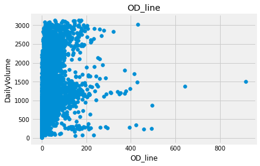

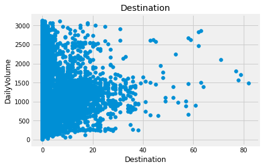

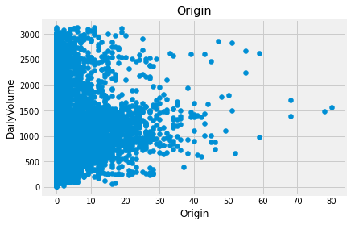

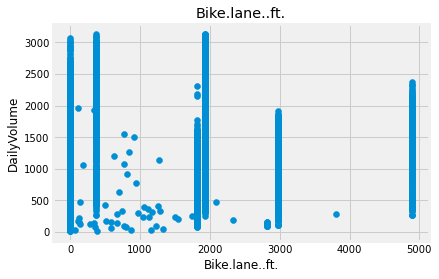

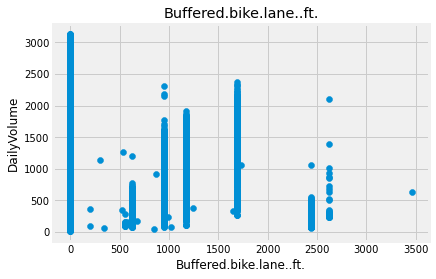

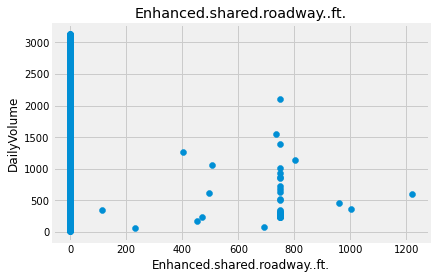

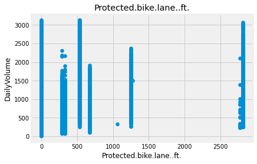

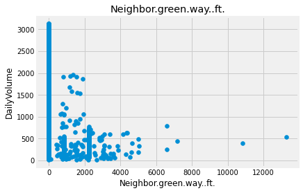

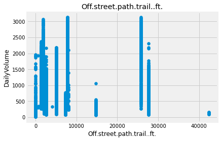

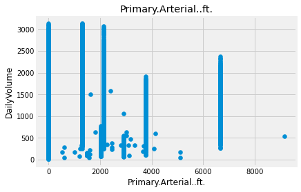

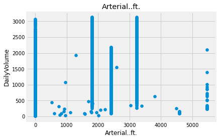

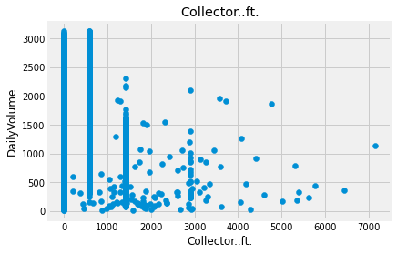

[33 more figures not shown]

```python
features = data_filled.drop("DailyVolume", axis=1)
target = data_filled["DailyVolume"]

# create scatterplots for each var with target var:
for i, col in enumerate(features.columns.values):
    #     plt.subplot(1, len(features), i+1)
    x = features[col]
    plt.scatter(x, target)
    plt.title(col)
    plt.xlabel(col)
    plt.ylabel("DailyVolume")
    plt.show()
```

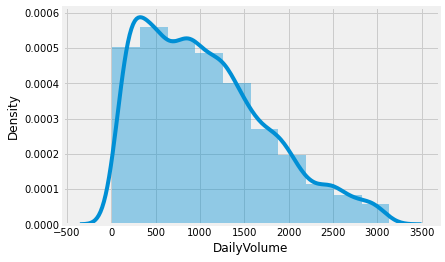

```python
# first we generate a histogram of our target variable to see how the data is distributed.
sns.distplot(data_filled["DailyVolume"], bins=10)
```

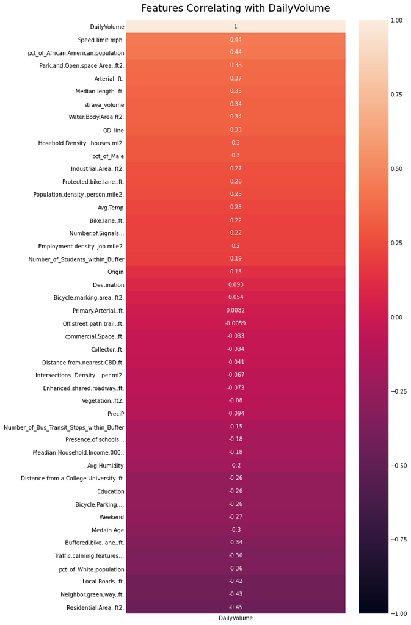

```python
# generate a Pearson correlation (r - coefficient of correlation) heatmap for our cleaned up data:

plt.figure(figsize=(8, 20))

data_filled_corr = data_filled.corr()[["DailyVolume"]].sort_values(
    by="DailyVolume", ascending=False)

heatmap = sns.heatmap(data_filled_corr, vmax=1, vmin=-1, annot=True)
heatmap.set_title("Features Correlating with DailyVolume",
                  fontdict={"fontsize": 18}, pad=16)

plt.savefig("figures/FeaturesCorrelatingWithDailyVolume.png",
            dpi=300, bbox_inches="tight")
```

## Preparing the Data for the ML Model

```python
# split data into X dataframe and Y dataframe:
X_data = data_filled.drop("DailyVolume", axis=1)
Y_data = data_filled["DailyVolume"]
print(f"X_data.shape: {X_data.shape} Y_data.shape: {Y_data.shape}")
```

```
X_data.shape: (6746, 45) Y_data.shape: (6746,)
```

```python
X = np.asarray(X_data)
Y = np.asarray(Y_data)
print(f"X.shape: {X.shape} Y.shape: {Y.shape}")
```

```
X.shape: (6746, 45) Y.shape: (6746,)
```

# First We Will Create an SNN With Original Feature Dimensions

```python
# set up variables for next cell:
start_time = None
elapsed_time = None

# these dicts store parameters for the lowest value achieved for each metric:
rmse_dict = {'root_mean_squared_error': 10000000000}
mape_dict = {'mean_absolute_percentage_error': 10000000000}
mae_dict = {'mean_absolute_error': 10000000000}

# num_inputs = X_train.shape[1]
# default learning rate for Adam is 0.001, maybe we can do a dynamic learning rate (lower as it goes).
learning_rate = 0.001
HL_1_nodes_max = 1024
activation_list = ['relu', 'linear']
loss_list = ['mse', 'mae']

metrics = [RootMeanSquaredError(), "mean_absolute_percentage_error",
           "mean_absolute_error"]
```

```python
num_folds = 10
kfold = KFold(n_splits=10, shuffle=True, random_state=1)

# Now we perform KFold:
# input_data = X
# target_data = Y

fold_num = 1
MAPE_train = []
MAPE_scores = []
RMSE_train = []
RMSE_scores = []
MAE_train = []
MAE_scores = []
R2_train = []
R2_scores = []
for train, test in kfold.split(X, Y):
    # This model's parameters were gathered using a brute-force loop. Shown further below.
    model = Sequential([
        Dense(1018, activation='relu', input_shape=(X.shape[1],)),
        Dense(1, activation='linear')
    ])
    model.compile(loss='mae', optimizer='adam', metrics=metrics)
    history = model.fit(
        X[train], Y[train], batch_size=128, epochs=1000, verbose=False)
    scores = model.evaluate(X[test], Y[test], verbose=False)
    predictions = model.predict(X[test])

    train_r2 = r2_score(Y[train], model.predict(X[train]))
    R2_train.append(train_r2)
    score_r2 = r2_score(Y[test], predictions)
    R2_scores.append(score_r2)
    MAPE_train.append(history.history.get(
        'mean_absolute_percentage_error')[-1])
    MAPE_scores.append(scores[2])
    RMSE_train.append(history.history.get('root_mean_squared_error')[-1])
    RMSE_scores.append(scores[1])
    MAE_train.append(history.history.get('loss')[-1])
    MAE_scores.append(scores[0])
    print(
        f"------------------------------------------Fold {fold_num}------------------------------------------")
    print(
        f"\tTrain Loss: {history.history.get('loss')[-1]}\tScore Loss: {scores[0]}")
    print(
        f"\tTrain RMSE: {history.history.get('root_mean_squared_error')[-1]}\tScore RMSE: {scores[1]}")
    print(
        f"\tTrain MAPE: {history.history.get('mean_absolute_percentage_error')[-1]}\tScore MAPE: {scores[2]}")
    print(f"\tTrain R2:   {train_r2}\tScore R2: {score_r2}")
    fold_num += 1


print(f"\n\nOverall MAE: {np.mean(MAE_scores)} +/- {np.std(MAE_scores)}")
print(f"Overall RMSE: {np.mean(RMSE_scores)} +/- {np.std(RMSE_scores)}")
print(f"Overall MAPE: {np.mean(MAPE_scores)} +/- {np.std(MAPE_scores)}")
print(f"Overall R2: {np.mean(R2_scores)*100} +/- {np.std(R2_scores)*100}\n\n")

print("Delimited table:")
print("MAPE\tRMSE\tMAE\tR2")
for i in range(0, 10):
    print("%.2f/%.2f\t%.2f/%.2f\t%.2f/%.2f\t%.2f/%.2f" %
          (MAPE_train[i], MAPE_scores[i], RMSE_train[i], RMSE_scores[i], MAE_train[i], MAE_scores[i], R2_train[i], R2_scores[i]))
print("%.2f/%.2f\t%.2f/%.2f\t%.2f/%.2f\t%.2f/%.2f\t<===Averages" % (np.mean(MAPE_train), np.mean(MAPE_scores),
      np.mean(RMSE_train), np.mean(RMSE_scores), np.mean(MAE_train), np.mean(MAE_scores), np.mean(R2_train), np.mean(R2_scores)))
```

```
------------------------------------------Fold 1------------------------------------------
	Train Loss: 256.71856689453125	Score Loss: 259.92236328125
	Train RMSE: 364.8098449707031	Score RMSE: 369.7839050292969
	Train MAPE: 37.70236587524414	Score MAPE: 36.075889587402344
	Train R2:   0.7465566604748812	Score R2: 0.7300529574540073
------------------------------------------Fold 2------------------------------------------
	Train Loss: 281.0909729003906	Score Loss: 237.5550537109375
	Train RMSE: 394.4443359375	Score RMSE: 338.6130065917969
	Train MAPE: 41.000247955322266	Score MAPE: 42.64749526977539
	Train R2:   0.743167825865685	Score R2: 0.7568153267140472
------------------------------------------Fold 3------------------------------------------
	Train Loss: 256.182373046875	Score Loss: 254.9861297607422
	Train RMSE: 364.239990234375	Score RMSE: 364.8460388183594
	Train MAPE: 38.018035888671875	Score MAPE: 36.57771682739258
	Train R2:   0.7520023185548509	Score R2: 0.7506616221330946
------------------------------------------Fold 4------------------------------------------
	Train Loss: 277.4768371582031	Score Loss: 312.4610290527344
	Train RMSE: 389.0046081542969	Score RMSE: 465.7312316894531
	Train MAPE: 40.90407943725586	Score MAPE: 46.24821853637695
	Train R2:   0.680216379594135	Score R2: 0.5518199591604523
------------------------------------------Fold 5------------------------------------------
	Train Loss: 264.8228454589844	Score Loss: 272.671630859375
	Train RMSE: 368.8822326660156	Score RMSE: 389.30853271484375
	Train MAPE: 39.095359802246094	Score MAPE: 37.3851318359375
	Train R2:   0.7109791714985935	Score R2: 0.7064386504392318
------------------------------------------Fold 6------------------------------------------
	Train Loss: 269.6882019042969	Score Loss: 253.7142791748047
	Train RMSE: 384.7589416503906	Score RMSE: 382.3572998046875
	Train MAPE: 39.175846099853516	Score MAPE: 38.249752044677734
	Train R2:   0.7398592513315536	Score R2: 0.6879285704516864
------------------------------------------Fold 7------------------------------------------
	Train Loss: 255.31851196289062	Score Loss: 283.27520751953125
	Train RMSE: 363.6560363769531	Score RMSE: 407.5226745605469
	Train MAPE: 39.075016021728516	Score MAPE: 42.103736877441406
	Train R2:   0.6845229937310189	Score R2: 0.6684571299276726
------------------------------------------Fold 8------------------------------------------
	Train Loss: 273.4642333984375	Score Loss: 280.2235107421875
	Train RMSE: 387.73040771484375	Score RMSE: 389.1849365234375
	Train MAPE: 39.81654357910156	Score MAPE: 45.42885208129883
	Train R2:   0.67116282916557	Score R2: 0.6798618470136168
```

[output cut: 16 more lines]

```


Delimited table:
MAPE	RMSE	MAE	R2
37.70/36.08	364.81/369.78	256.72/259.92	0.75/0.73
41.00/42.65	394.44/338.61	281.09/237.56	0.74/0.76
38.02/36.58	364.24/364.85	256.18/254.99	0.75/0.75
40.90/46.25	389.00/465.73	277.48/312.46	0.68/0.55
39.10/37.39	368.88/389.31	264.82/272.67	0.71/0.71
39.18/38.25	384.76/382.36	269.69/253.71	0.74/0.69
39.08/42.10	363.66/407.52	255.32/283.28	0.68/0.67
39.82/45.43	387.73/389.18	273.46/280.22	0.67/0.68
39.12/41.09	367.14/375.16	258.73/264.44	0.76/0.71
38.81/32.41	370.72/380.33	257.37/281.10	0.74/0.72
39.27/39.82	375.54/386.28	265.09/270.04	0.72/0.70	<===Averages
```

# Route 1: Use PCA for Dimensionality Reduction

## First, we need to determine how many PCA components to use:

### Method 1: Scree Plot

We can use a `scree` plot to determine how many components to reduce to.

src: https://towardsdatascience.com/a-one-stop-shop-for-principal-component-analysis-5582fb7e0a9c

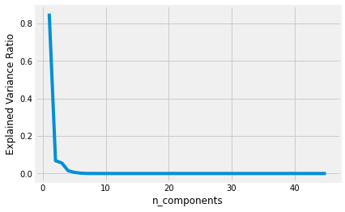

```python
pca_2 = PCA(n_components=45)
pca_2.fit_transform(X_data)
plt.plot(range(1, 46), pca_2.explained_variance_ratio_)
plt.ylabel("Explained Variance Ratio")
plt.xlabel("n_components")
plt.show()
```

The scree plot above shows an `elbow` right at the 5 components mark. This means we can get most of our information from 5 components.

### Method 2: Threshold of Explained Variance Approach

We can also choose the number of PCA components based on the threshold of variance_explained approach, as shown below. In this case, the standard cumulative variance_explained to aim for is 70%, however we can see that even 1 component gets us 85% alone.

```python
# threshold of variance explained approach. In this case, we hold on to principal components that explain at least 70%
# of the variance cumulatively
# https://www.datasklr.com/principal-component-analysis-and-factor-analysis/principal-component-analysis
print("Proportion of variance:")
print(pca_2.explained_variance_ratio_)
print("Cumulative variance:")
print(np.cumsum(pca_2.explained_variance_ratio_))
```

```
Proportion of variance:
[8.52650714e-01 6.79216898e-02 5.61671344e-02 1.48668984e-02
 5.94797404e-03 1.98230575e-03 2.48862329e-04 1.05546217e-04
 6.87824792e-05 3.14814755e-05 4.18092473e-06 2.01640371e-06
 1.02998429e-06 4.91866692e-07 3.48469276e-07 2.50413414e-07
 1.34138381e-07 6.38914180e-08 4.41583822e-08 2.59626313e-08
 1.10967176e-08 4.72820410e-09 4.00590946e-09 1.67020295e-09
 1.49438860e-09 8.65622843e-10 6.42773116e-10 1.79749398e-10
 1.37924462e-10 5.53807572e-11 3.94736893e-11 4.19761563e-12
 2.97163538e-12 9.92040509e-13 6.85900914e-13 3.43311573e-13
 2.28882407e-13 1.81790496e-13 1.54323249e-13 1.41919584e-13
 9.97715498e-14 6.35556214e-14 2.91552384e-14 1.01452560e-14
 9.58937969e-15]
Cumulative variance:
[0.85265071 0.9205724  0.97673954 0.99160644 0.99755441 0.99953672
 0.99978558 0.99989112 0.99995991 0.99999139 0.99999557 0.99999759
 0.99999862 0.99999911 0.99999946 0.99999971 0.99999984 0.9999999
 0.99999995 0.99999998 0.99999999 0.99999999 0.99999999 1.
 1.         1.         1.         1.         1.         1.
 1.         1.         1.         1.         1.         1.
 1.         1.         1.         1.         1.         1.
 1.         1.         1.        ]
```

### Method 3: Choosing A Variance Value Between 0.95 and 0.99

Here is our selected method. We have placed this method inside of a pipeline. This pipeline will scale the X data, as well as apply dimensionality reduction. The scaling of the data can be done via a minMaxScaler, or a StandardScaler().

In our case, PCA yields:

| Variance | n_components |
| --- | --- |
| 0.95 | 18 |
| 0.99 | 25 |

```python
n_components = 0.99

pipe = Pipeline([("scaler", StandardScaler()),
                ("pca", PCA(n_components=n_components))])
```

```python
# We dont need to split. KFold does the split for us.

# X_train, X_test, Y_train, Y_test = train_test_split(X, Y, test_size=0.2,random_state=42)
# print(f"X_train.shape: {X_train.shape} X_test.shape: {X_test.shape} Y_train.shape: {Y_train.shape} Y_test.shape: {Y_test.shape}")
```

## We Loop Through Possible Parameters to Generate A Shallow Neural Network

Since our dataset is small (~7000 samples), and the problem we tackling is multi-regression, we can try to brute force the solution.

According to Cybenko's Theorem, any continuous function can be approximated using a NN that has only one hidden layer.

We use this to our advantage, brute forcing the best NN parameters. Each run of this loop costs us about 9 hours in runtime, and objectively gives us the best parameters.

```python
# set up variables for next cell:
start_time = None
elapsed_time = None

# these dicts store parameters for the lowest value achieved for each metric:
rmse_dict = {'root_mean_squared_error': 10000000000}
mape_dict = {'mean_absolute_percentage_error': 10000000000}
mae_dict = {'mean_absolute_error': 10000000000}

# default learning rate for Adam is 0.001, maybe we can do a dynamic learning rate (lower as it goes).
learning_rate = 0.001
HL_1_nodes_max = 1024
activation_list = ['relu', 'linear']
loss_list = ['mse', 'mae']

metrics = [RootMeanSquaredError(), "mean_absolute_percentage_error",
           "mean_absolute_error"]

# num_inputs = X_train.shape[1]
```

```python
def update_dict(x_dict, num_inputs, learning_rate, num_HL_nrns, HL1_ac_fn, HL2_ac_fn):
    x_dict['num_inputs'] = num_inputs
    x_dict['learning_rate'] = learning_rate
    x_dict['num_HL_nrns'] = num_HL_nrns
    x_dict['HL1_ac_fn'] = HL1_ac_fn
    x_dict['HL2_ac_fn'] = HL2_ac_fn
    x_dict['n_components'] = n_components


for num_HL_nrns in range(1, HL_1_nodes_max+1):
    if elapsed_time is not None:
        elapsed_time = elapsed_time*(HL_1_nodes_max-num_HL_nrns)
        print(
            f"\tTime Remaining: {int((elapsed_time//60)//60)}:{int((elapsed_time//60)%60)}:{int(elapsed_time%60)}", end="")
        print(
            f'\tETC: {time.strftime("%I:%Mp", time.localtime(time.time()+elapsed_time))}')
    start_time = time.process_time()

    for HL1_ac_fn in range(len(activation_list)):
        for HL2_ac_fn in range(len(activation_list)):
            for loss_fn in range(len(loss_list)):
                model = Sequential([
                    Dense(num_HL_nrns, activation=activation_list[HL1_ac_fn], input_shape=(
                        X_train.shape[1],)),
                    Dense(1, activation=activation_list[HL2_ac_fn])
                ])
                model.compile(loss=loss_list[loss_fn],
                              optimizer='adam', metrics=metrics)
                history = model.fit(X_train, Y_train, batch_size=128,
                                    verbose=False, epochs=100, validation_data=(X_test, Y_test))
                with open("rf_importance_models_logs.txt", "a") as file:
                    results = model.evaluate(X_test, Y_test, verbose=False)
                    file.write(
                        "\n++++++++++++++++++++++++++++++++++++++++++++++++++++++++++++++++++++++++++++++++++++++++++++\n")
                    file.write(f"learning_rate: {learning_rate} ")
                    file.write(f"num_inputs: {num_inputs} ")
                    file.write(
                        f"num_HL_nrns: {num_HL_nrns} HL1_ac_fn: {activation_list[HL1_ac_fn]} ")
                    file.write(f"output_ac_fn: {activation_list[HL2_ac_fn]} ")
                    file.write(f"loss_fn: {loss_list[loss_fn]}\n")
                    # https://machinelearningmastery.com/display-deep-learning-model-training-history-in-keras/
                    for key in history.history.keys():
                        file.write(f"{key}: {history.history.get(key)[-1]}\n")
                    file.write("Evaluation:\n")
                    for i, metric in enumerate(model.metrics_names):
                        file.write(f"{metric}: {results[i]} ")
                if history.history.get('root_mean_squared_error')[-1] <= rmse_dict['root_mean_squared_error']:
                    rmse_dict['root_mean_squared_error'] = history.history.get(
                        'root_mean_squared_error')[-1]
                    update_dict(rmse_dict, num_inputs, learning_rate, num_HL_nrns,
                                activation_list[HL1_ac_fn], activation_list[HL2_ac_fn])
                if history.history.get('mean_absolute_percentage_error')[-1] <= mape_dict['mean_absolute_percentage_error']:
                    mape_dict['mean_absolute_percentage_error'] = history.history.get(
                        'mean_absolute_percentage_error')[-1]
                    update_dict(mape_dict, num_inputs, learning_rate, num_HL_nrns,
                                activation_list[HL1_ac_fn], activation_list[HL2_ac_fn])
                if history.history.get('mean_absolute_error')[-1] <= mae_dict['mean_absolute_error']:
                    mae_dict['mean_absolute_error'] = history.history.get(
                        'mean_absolute_error')[-1]
                    update_dict(mae_dict, num_inputs, learning_rate, num_HL_nrns,
                                activation_list[HL1_ac_fn], activation_list[HL2_ac_fn])
    elapsed_time = time.process_time() - start_time
    print(f"HL1 neurons {num_HL_nrns} done.", end="")
```

```
HL1 neurons 1 done.	Time Remaining: 9:14:38	ETC: 02:18p
HL1 neurons 2 done.	Time Remaining: 9:5:3	ETC: 02:09p
HL1 neurons 3 done.	Time Remaining: 9:26:18	ETC: 02:30p
HL1 neurons 4 done.	Time Remaining: 8:54:58	ETC: 01:59p
HL1 neurons 5 done.	Time Remaining: 9:11:9	ETC: 02:16p
HL1 neurons 6 done.	Time Remaining: 9:39:12	ETC: 02:44p
HL1 neurons 7 done.	Time Remaining: 9:11:23	ETC: 02:17p
HL1 neurons 8 done.	Time Remaining: 9:7:8	ETC: 02:13p
HL1 neurons 9 done.	Time Remaining: 10:8:55	ETC: 03:15p
HL1 neurons 10 done.	Time Remaining: 10:23:53	ETC: 03:30p
HL1 neurons 11 done.	Time Remaining: 10:26:42	ETC: 03:34p
HL1 neurons 12 done.	Time Remaining: 10:38:59	ETC: 03:46p
HL1 neurons 13 done.	Time Remaining: 10:20:12	ETC: 03:28p
HL1 neurons 14 done.	Time Remaining: 10:37:27	ETC: 03:46p
HL1 neurons 15 done.	Time Remaining: 10:24:29	ETC: 03:33p
HL1 neurons 16 done.	Time Remaining: 10:40:7	ETC: 03:49p
HL1 neurons 17 done.	Time Remaining: 10:38:10	ETC: 03:47p
HL1 neurons 18 done.	Time Remaining: 10:29:57	ETC: 03:40p
HL1 neurons 19 done.	Time Remaining: 11:3:50	ETC: 04:14p
HL1 neurons 20 done.	Time Remaining: 10:37:50	ETC: 03:48p
HL1 neurons 21 done.	Time Remaining: 10:47:38	ETC: 03:58p
HL1 neurons 22 done.	Time Remaining: 10:33:58	ETC: 03:45p
HL1 neurons 23 done.	Time Remaining: 11:3:32	ETC: 04:15p
HL1 neurons 24 done.	Time Remaining: 11:27:4	ETC: 04:39p
HL1 neurons 25 done.	Time Remaining: 11:13:54	ETC: 04:26p
HL1 neurons 26 done.	Time Remaining: 10:31:41	ETC: 03:44p
HL1 neurons 27 done.	Time Remaining: 10:48:10	ETC: 04:01p
HL1 neurons 28 done.	Time Remaining: 10:56:20	ETC: 04:10p
HL1 neurons 29 done.	Time Remaining: 10:50:45	ETC: 04:04p
HL1 neurons 30 done.	Time Remaining: 10:57:5	ETC: 04:11p
HL1 neurons 31 done.	Time Remaining: 10:34:43	ETC: 03:49p
HL1 neurons 32 done.	Time Remaining: 11:3:30	ETC: 04:18p
HL1 neurons 33 done.	Time Remaining: 10:40:24	ETC: 03:56p
HL1 neurons 34 done.	Time Remaining: 10:54:57	ETC: 04:11p
HL1 neurons 35 done.	Time Remaining: 10:36:32	ETC: 03:53p
HL1 neurons 36 done.	Time Remaining: 10:25:36	ETC: 03:42p
HL1 neurons 37 done.	Time Remaining: 10:40:54	ETC: 03:58p
HL1 neurons 38 done.	Time Remaining: 10:29:43	ETC: 03:47p
HL1 neurons 39 done.	Time Remaining: 10:35:14	ETC: 03:53p
HL1 neurons 40 done.	Time Remaining: 10:56:36	ETC: 04:15p
```

[output cut: 969 more lines]

```
HL1 neurons 1010 done.	Time Remaining: 0:38:39	ETC: 08:01p
HL1 neurons 1011 done.	Time Remaining: 0:34:33	ETC: 07:59p
HL1 neurons 1012 done.	Time Remaining: 0:31:52	ETC: 07:57p
HL1 neurons 1013 done.	Time Remaining: 0:28:32	ETC: 07:55p
HL1 neurons 1014 done.	Time Remaining: 0:25:53	ETC: 07:54p
HL1 neurons 1015 done.	Time Remaining: 0:22:14	ETC: 07:52p
HL1 neurons 1016 done.	Time Remaining: 0:19:26	ETC: 07:51p
HL1 neurons 1017 done.	Time Remaining: 0:17:22	ETC: 07:50p
HL1 neurons 1018 done.	Time Remaining: 0:14:18	ETC: 07:49p
HL1 neurons 1019 done.	Time Remaining: 0:12:45	ETC: 07:48p
HL1 neurons 1020 done.	Time Remaining: 0:8:31	ETC: 07:46p
HL1 neurons 1021 done.	Time Remaining: 0:5:44	ETC: 07:44p
HL1 neurons 1022 done.	Time Remaining: 0:2:51	ETC: 07:43p
HL1 neurons 1023 done.	Time Remaining: 0:0:0	ETC: 07:42p
HL1 neurons 1024 done.
```

## Results of the PCA Shallow NNs

| n_components | RMSE | MAPE | MAE | learning_rate | hidden_layer_nrns | HL_ac_fn | output_layer_ac_fn |
| --- | --- | --- | --- | --- | --- | --- | --- |
| 18 | 281.390714 | - | - | 0.001 | 1024 | relu | linear |
|  | - | 23.558494 | - | 0.001 | 1021 | relu | linear |
|  | - | - | 176.919 | 0.001 | 1024 | relu | relu |
| 25 | 274.9177 | - | - | 0.001 | 589 | relu | linear |
|  | - | 21.593589 | - | 0.001 | 584 | relu | relu |
|  | - | - | 172.786 | 0.001 | 566 | relu | linear |

Our most important metric is Mean Absolute Percentage Error. Based on this, we can choose the SNN model that has the best MAPE. We then run 10-Fold Cross Validation to further test the generalizablity of the model, and to see if our model displayed any signs of overfitting.

```python
num_folds = 10
kfold = KFold(n_splits=10, shuffle=True, random_state=1)

# Now we perform KFold:
# input_data = X
# target_data = Y

fold_num = 1
MAPE_train = []
MAPE_scores = []
RMSE_train = []
RMSE_scores = []
MAE_train = []
MAE_scores = []
R2_train = []
R2_scores = []
for train, test in kfold.split(X, Y):
    # we use the pipeline from earlier:
    train_piped = pipe.fit_transform(X[train])
    test_piped = pipe.transform(X[test])
    # now our data is ready to go into our model.
    model = Sequential([
        Dense(584, activation='relu', input_shape=(train_piped.shape[1],)),
        Dense(1, activation='relu')
    ])
    model.compile(loss='mae', optimizer='adam', metrics=metrics)
    history = model.fit(
        train_piped, Y[train], batch_size=128, epochs=1000, verbose=False)
    scores = model.evaluate(test_piped, Y[test], verbose=False)
    predictions = model.predict(test_piped)

    train_r2 = r2_score(Y[train], model.predict(train_piped))
    R2_train.append(train_r2)
    score_r2 = r2_score(Y[test], predictions)
    R2_scores.append(score_r2)
    MAPE_train.append(history.history.get(
        'mean_absolute_percentage_error')[-1])
    MAPE_scores.append(scores[2])
    RMSE_train.append(history.history.get('root_mean_squared_error')[-1])
    RMSE_scores.append(scores[1])
    MAE_train.append(history.history.get('loss')[-1])
    MAE_scores.append(scores[0])
    print(
        f"------------------------------------------Fold {fold_num}------------------------------------------")
    print(
        f"\tTrain Loss: {history.history.get('loss')[-1]}\tScore Loss: {scores[0]}")
    print(
        f"\tTrain RMSE: {history.history.get('root_mean_squared_error')[-1]}\tScore RMSE: {scores[1]}")
    print(
        f"\tTrain MAPE: {history.history.get('mean_absolute_percentage_error')[-1]}\tScore MAPE: {scores[2]}")
    print(f"\tTrain R2:   {train_r2}\tScore R2: {score_r2}")
    fold_num += 1


print(f"\n\nOverall MAE: {np.mean(MAE_scores)} +/- {np.std(MAE_scores)}")
print(f"Overall RMSE: {np.mean(RMSE_scores)} +/- {np.std(RMSE_scores)}")
print(f"Overall MAPE: {np.mean(MAPE_scores)} +/- {np.std(MAPE_scores)}")
print(f"Overall R2: {np.mean(R2_scores)*100} +/- {np.std(R2_scores)*100}\n\n")

print("Delimited table:")
print("MAPE\tRMSE\tMAE\tR2")
for i in range(0, 10):
    print("%.2f/%.2f\t%.2f/%.2f\t%.2f/%.2f\t%.2f/%.2f" %
          (MAPE_train[i], MAPE_scores[i], RMSE_train[i], RMSE_scores[i], MAE_train[i], MAE_scores[i], R2_train[i], R2_scores[i]))
print("%.2f/%.2f\t%.2f/%.2f\t%.2f/%.2f\t%.2f/%.2f\t<===Averages" % (np.mean(MAPE_train), np.mean(MAPE_scores),
      np.mean(RMSE_train), np.mean(RMSE_scores), np.mean(MAE_train), np.mean(MAE_scores), np.mean(R2_train), np.mean(R2_scores)))
```

```
------------------------------------------Fold 1------------------------------------------
	Train Loss: 143.2643585205078	Score Loss: 164.89505004882812
	Train RMSE: 252.6852264404297	Score RMSE: 275.4474182128906
	Train MAPE: 18.02696418762207	Score MAPE: 25.773536682128906
	Train R2:   0.8706763813328856	Score R2: 0.8502179075571271
------------------------------------------Fold 2------------------------------------------
	Train Loss: 143.46157836914062	Score Loss: 147.63180541992188
	Train RMSE: 256.91363525390625	Score RMSE: 234.9132843017578
	Train MAPE: 18.31273078918457	Score MAPE: 23.26551628112793
	Train R2:   0.8689958294804443	Score R2: 0.8829573712138945
------------------------------------------Fold 3------------------------------------------
	Train Loss: 142.4607391357422	Score Loss: 158.4708251953125
	Train RMSE: 252.0089111328125	Score RMSE: 265.0783386230469
	Train MAPE: 18.152420043945312	Score MAPE: 22.960018157958984
	Train R2:   0.871429272993466	Score R2: 0.8683810593448973
------------------------------------------Fold 4------------------------------------------
	Train Loss: 142.14599609375	Score Loss: 163.63966369628906
	Train RMSE: 252.8638458251953	Score RMSE: 289.9974670410156
	Train MAPE: 18.21141815185547	Score MAPE: 35.27389907836914
	Train R2:   0.8715681926880942	Score R2: 0.8262318482073234
------------------------------------------Fold 5------------------------------------------
	Train Loss: 139.98089599609375	Score Loss: 175.80447387695312
	Train RMSE: 249.364501953125	Score RMSE: 295.1587219238281
	Train MAPE: 18.177499771118164	Score MAPE: 24.546119689941406
	Train R2:   0.8746375520657469	Score R2: 0.831258342360339
------------------------------------------Fold 6------------------------------------------
	Train Loss: 143.91384887695312	Score Loss: 152.43321228027344
	Train RMSE: 254.7238006591797	Score RMSE: 261.4229736328125
	Train MAPE: 18.436952590942383	Score MAPE: 21.45199203491211
	Train R2:   0.8702397342794701	Score R2: 0.8541176624193113
------------------------------------------Fold 7------------------------------------------
	Train Loss: 142.3927764892578	Score Loss: 162.96112060546875
	Train RMSE: 250.8924102783203	Score RMSE: 282.670654296875
	Train MAPE: 18.21690559387207	Score MAPE: 21.123991012573242
	Train R2:   0.8727981020606369	Score R2: 0.840486443602521
------------------------------------------Fold 8------------------------------------------
	Train Loss: 144.0885772705078	Score Loss: 150.16566467285156
	Train RMSE: 255.05551147460938	Score RMSE: 256.58502197265625
	Train MAPE: 18.33052635192871	Score MAPE: 24.611209869384766
	Train R2:   0.8693745046566657	Score R2: 0.8608484686112625
```

[output cut: 16 more lines]

```


Delimited table:
MAPE	RMSE	MAE	R2
18.03/25.77	252.69/275.45	143.26/164.90	0.87/0.85
18.31/23.27	256.91/234.91	143.46/147.63	0.87/0.88
18.15/22.96	252.01/265.08	142.46/158.47	0.87/0.87
18.21/35.27	252.86/290.00	142.15/163.64	0.87/0.83
18.18/24.55	249.36/295.16	139.98/175.80	0.87/0.83
18.44/21.45	254.72/261.42	143.91/152.43	0.87/0.85
18.22/21.12	250.89/282.67	142.39/162.96	0.87/0.84
18.33/24.61	255.06/256.59	144.09/150.17	0.87/0.86
18.32/23.73	254.14/281.40	143.95/160.06	0.87/0.83
18.40/19.47	254.69/251.58	142.29/161.50	0.87/0.88
18.26/24.22	253.33/269.43	142.79/159.76	0.87/0.85	<===Averages
```

# Route 2: Use Random Forest for Dimensionality Reduction

We can use RF to obtain the 'importance' of each feature. The importance measures the mean Gini Impurity of all trees.

## First We Create a Random Forest Model

### Create a Random Hyperparameter Grid

```python
# Number of trees in random forest
n_estimators = [int(x) for x in np.linspace(start=50, stop=2000, num=10)]
# Number of features to consider at every split
max_features = ['auto', 'sqrt']
# Maximum number of levels in tree
max_depth = [int(x) for x in np.linspace(10, 110, num=11)]
max_depth.append(None)
# Minimum number of samples required to split a node
min_samples_split = [2, 5, 10]
# Minimum number of samples required at each leaf node
min_samples_leaf = [1, 2, 4]
# Method of selecting samples for training each tree
bootstrap = [True, False]
# Whether to use out-of-bag samples to estimate the generalization accuracy.
oob_score = [True, False]
# Create the random grid
random_grid = {'n_estimators': n_estimators,
               'max_features': max_features,
               'max_depth': max_depth,
               'min_samples_split': min_samples_split,
               'min_samples_leaf': min_samples_leaf,
               'bootstrap': bootstrap,
               'oob_score': oob_score}
pprint(random_grid)
```

```
{'bootstrap': [True, False],
 'max_depth': [10, 20, 30, 40, 50, 60, 70, 80, 90, 100, 110, None],
 'max_features': ['auto', 'sqrt'],
 'min_samples_leaf': [1, 2, 4],
 'min_samples_split': [2, 5, 10],
 'n_estimators': [50, 266, 483, 700, 916, 1133, 1350, 1566, 1783, 2000],
 'oob_score': [True, False]}
```

```python
X_train1, X_test1, Y_train1, Y_test1 = train_test_split(
    X, Y, test_size=0.2, random_state=1231)
```

```python
# Use the random grid to search for best hyperparameters
# First create the base model to tune
rf = RandomForestRegressor()
# Random search of parameters, using 3 fold cross validation,This calculation is very costly.
# search across 300 different combinations, and use all available cores
rf_random = RandomizedSearchCV(estimator=rf, param_distributions=random_grid, n_iter=100,
                               cv=3, verbose=2, random_state=42, n_jobs=-1)  # Fit the random search model
rf_random.fit(X_train1, Y_train1)
```

```
Fitting 3 folds for each of 100 candidates, totalling 300 fits
```

```
RandomizedSearchCV(cv=3, estimator=RandomForestRegressor(), n_iter=100,
                   n_jobs=-1,
                   param_distributions={'bootstrap': [True, False],
                                        'max_depth': [10, 20, 30, 40, 50, 60,
                                                      70, 80, 90, 100, 110,
                                                      None],
                                        'max_features': ['auto', 'sqrt'],
                                        'min_samples_leaf': [1, 2, 4],
                                        'min_samples_split': [2, 5, 10],
                                        'n_estimators': [50, 266, 483, 700, 916,
                                                         1133, 1350, 1566, 1783,
                                                         2000],
                                        'oob_score': [True, False]},
                   random_state=42, verbose=2)
```

```python
rf_random.best_params_
```

```
{'oob_score': False,
 'n_estimators': 266,
 'min_samples_split': 2,
 'min_samples_leaf': 1,
 'max_features': 'sqrt',
 'max_depth': 40,
 'bootstrap': True}
```

Since we have already created a RF model with tuned hyperparameters, we will go ahead and measure all of the metrics of that model.

```python
best_random = rf_random.best_estimator_

print("Training Evaluation")
training_accuracy = evaluate(best_random, X_train1, Y_train1)
Train_prediction_rf = best_random.predict(X_train1)

# Use the forest's predict method on the test data
predictions = best_random.predict(X_test1)  # Calculate the absolute errors
print("\nTesting Evaluation")
testing_accuracy = evaluate(best_random, X_test1, Y_test1)

# src: https://datascience.stackexchange.com/questions/13151/randomforestclassifier-oob-scoring-method#:~:text=random%2Dforest%20scikit%2Dlearn,method%20reports%20the%20mean%20accuracy.
# here we print the training score of our model:
print("\nTraining Score: ", best_random.score(X_train1, Y_train1))
# next we print the score for the testing set:
print("Testing Score: ", best_random.score(X_test1, Y_test1))

# More metrics for our training and testing.
Training_MAE = mean_absolute_error(Y_train1, Train_prediction_rf)
Training_APE = sum(
    np.abs(((Train_prediction_rf-Y_train1)/Y_train1)))/Y_train1.shape[0]*100
Training_RMSE = math.sqrt(mean_squared_error(Y_train1, Train_prediction_rf))
Training_R2 = r2_score(Y_train1, Train_prediction_rf)

Testing_MAE = mean_absolute_error(Y_test1, predictions)
Testing_APE = sum(np.abs(((predictions-Y_test1)/Y_test1)))/Y_test1.shape[0]*100
Testing_RMSE = math.sqrt(mean_squared_error(Y_test1, predictions))
Testing_R2 = r2_score(Y_test1, predictions)

print(f"\n\nTraining MAE:  {Training_MAE}\tTesting MAE: {Testing_MAE}")
print(f"Training RMSE: {Training_RMSE}\tTesting RMSE: {Testing_RMSE}")
print(f"Training APE:  {Training_APE}\tTesting APE: {Testing_APE}")
print(f"Training R2:   {Training_R2}\tTesting R2: {Testing_R2}")
```

```
Training Evaluation
Average Error: 61.2186 degrees.
Accuracy = 90.91%.

Testing Evaluation
Average Error: 173.5171 degrees.
Accuracy = 74.25%.

Training Score:  0.981312145748052
Testing Score:  0.8569377167115498


Training MAE:  61.21864462397655	Testing MAE: 173.51714842662213
Training RMSE: 96.28336431980257	Testing RMSE: 265.8659902819868
Training APE:  9.086273701118532	Testing APE: 25.754805139824178
Training R2:   0.981312145748052	Testing R2: 0.8569377167115498
```

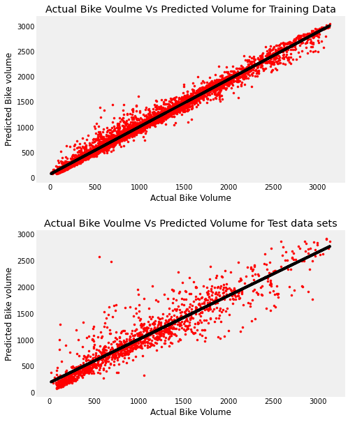

```python
plt.rcParams["figure.figsize"] = (7, 10)
plt.subplot(2, 1, 1)
# plot actual Vs prediction for training data set
plt.scatter(Y_train1, Train_prediction_rf, marker='.', color='red')
z = np.polyfit(Y_train1, Train_prediction_rf, 1)
z = np.squeeze(z)
p = np.poly1d(z)
plt.grid(alpha=0.3)
plt.xlabel('Actual Bike Volume')
plt.ylabel('Predicted Bike volume')
plt.title('Actual Bike Voulme Vs Predicted Volume for Training Data')
plt.plot(Y_train1, p(Y_train1), "k-")

plt.subplot(2, 1, 2)
# plot actual Vs prediction for testing data set
plt.scatter(Y_test1, predictions, marker='.', color='red')
z = np.polyfit(Y_test1, predictions, 1)
z = np.squeeze(z)
p = np.poly1d(z)
plt.grid(alpha=0.3)
plt.xlabel('Actual Bike Volume')
plt.ylabel('Predicted Bike volume')
plt.title('Actual Bike Voulme Vs Predicted Volume for Test data sets')
plt.plot(Y_test1, p(Y_test1), "k-")

plt.subplots_adjust(hspace=0.3)
```

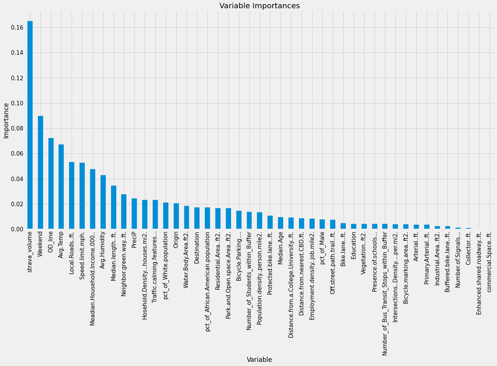

```python
feature_importances_df = pd.DataFrame(best_random.feature_importances_, index=X_data.columns, columns=[
                                      'Importance']).sort_values('Importance', ascending=False)
feature_importances_df.plot(kind='bar', figsize=(20, 10), style='fivethirtyeight', fontsize=15, legend=False,
                            title="Variable Importances", ylabel="Importance", xlabel="Variable")
```

```python
# https://stackoverflow.com/questions/44487654/build-a-random-forest-regressor-with-cross-validation-from-scratch
```

## Using That Random Forest Model To Do Dimensionality Reduction

We can get the best hyperparameter model for the Random Forest we did earlier. We can use that model to select variables based on their importance (we would choose an arbitrary value for cutoff).

[output not shown]

In the next cell, we will drop the respective columns based on the arbitrary cutoff values.

```python
_0_cutoff = ['DailyVolume', 'Bike.lane..ft.', 'Buffered.bike.lane..ft.', 'Enhanced.shared.roadway..ft.', 'Primary.Arterial..ft.',
             'Collector..ft.', 'Intersections..Density....per.mi2.', 'Bicycle.marking.area..ft2.', 'Number.of.Signals...',
             'Industrial.Area..ft2.', 'commercial.Space..ft.', 'Vegetation..ft2.', 'Presence.of.schools...', 'pct_of_Male']
_0_1_cutoff = ['Protected.bike.lane..ft.', 'Off.street.path.trail..ft.', 'Arterial..ft.', 'Number_of_Bus_Transit_Stops_within_Buffer',
               'Population.density..person.mile2.', 'Employment.density..job.mile2.', 'Park.and.Open.space.Area..ft2.',
               'Residential.Area..ft2.', 'Distance.from.nearest.CBD.ft.', 'Distance.from.a.College.University..ft.', 'Number_of_Students_within_Buffer',
               'Medain.Age', 'pct_of_African.American.population', 'Education']
_0_1_cutoff.extend(_0_cutoff)
_0_2_cutoff = ['Destination', 'Traffic.calming.features...', 'Hosehold.Density...houses.mi2.', 'Bicycle.Parking....',
               'Water.Body.Area.ft2.', 'pct_of_White.population']
_0_2_cutoff.extend(_0_1_cutoff)
_0_3_cutoff = ['Origin', 'Neighbor.green.way..ft.',
               'Median.length..ft.', 'PreciP']
_0_3_cutoff.extend(_0_2_cutoff)
_0_4_cutoff = ['Meadian.Household.Income.000..']
_0_4_cutoff.extend(_0_3_cutoff)

# for vars > 0.0 importance
features_0_cutoff = data_filled.drop(_0_cutoff, axis=1)
features_0_cutoff = np.asarray(features_0_cutoff)
# for vars > 0.01 importance
features_0_1_cutoff = data_filled.drop(_0_1_cutoff, axis=1)
features_0_1_cutoff = np.asarray(features_0_1_cutoff)
# for vars > 0.02 importance
features_0_2_cutoff = data_filled.drop(_0_2_cutoff, axis=1)
features_0_2_cutoff = np.asarray(features_0_2_cutoff)
# for vars > 0.03 importance
features_0_3_cutoff = data_filled.drop(_0_3_cutoff, axis=1)
features_0_3_cutoff = np.asarray(features_0_3_cutoff)
# for vars > 0.04 importance
features_0_4_cutoff = data_filled.drop(_0_4_cutoff, axis=1)
features_0_4_cutoff = np.asarray(features_0_4_cutoff)
```

```python
# We dont need to split. KFold does the split for us.
X_train, X_test, Y_train, Y_test = train_test_split(
    features_0_cutoff, Y, test_size=0.2, random_state=42)

print(f"X_train.shape: {X_train.shape} X_test.shape: {X_test.shape} Y_train.shape: {Y_train.shape} Y_test.shape: {Y_test.shape}")
```

```
X_train.shape: (5396, 32) X_test.shape: (1350, 32) Y_train.shape: (5396,) Y_test.shape: (1350,)
```

```python
print("------------------features_0_cutoff------------------")
# print out the dict vals:
print(rmse_dict)
print(mape_dict)
print(mae_dict)
```

```
------------------features_0_cutoff------------------
{'root_mean_squared_error': 460.6684265136719, 'num_inputs': 32, 'learning_rate': 0.001, 'num_HL_nrns': 507, 'HL1_ac_fn': 'relu', 'HL2_ac_fn': 'linear', 'n_components': 18}
{'mean_absolute_percentage_error': 61.90659713745117, 'num_inputs': 32, 'learning_rate': 0.001, 'num_HL_nrns': 507, 'HL1_ac_fn': 'relu', 'HL2_ac_fn': 'linear', 'n_components': 18}
{'mean_absolute_error': 353.9783020019531, 'num_inputs': 32, 'learning_rate': 0.001, 'num_HL_nrns': 507, 'HL1_ac_fn': 'relu', 'HL2_ac_fn': 'linear', 'n_components': 18}
```

## Results of Random Forest Cutoffs

| **Importance Cutoff (n_components)** | **RMSE** | **MAPE** | **MAE** | **learning_rate** | **hidden_layer_nrns** | **HL_ac_fn** | **output_layer_ac_fn** |
| --- | --- | --- | --- | --- | --- | --- | --- |
| 0.0 (32) | 460.668426 | - | - | 0.001 | 507 | relu | linear |
|  | - | 61.906597 | - | 0.001 | 507 | relu | linear |
|  | - | - | 353.978 | 0.001 | 507 | relu | linear |
| 0.01 (18) | 416.045104 | - | - | 0.001 | 1008 | relu | linear |
|  | - | 51.661293 | - | 0.001 | 18 | relu | linear |
|  | - | - | 313.622 | 0.001 | 1008 | relu | linear |
| 0.02 (12) | 290.293365 | - | - | 0.001 | 991 | relu | linear |
|  | - | 26.060958 | - | 0.001 | 986 | relu | relu |
|  | - | - | 184.928 | 0.001 | 999 | relu | linear |
| 0.03 (8) | 302.357116 | - | - | 0.001 | 1004 | relu | linear |
|  | - | 29.242176 | - | 0.001 | 884 | relu | linear |
|  | - | - | 199.044 | 0.001 | 1016 | relu | linear |
| 0.04 (7) | 333.882629 | - | - | 0.001 | 986 | relu | relu |
|  | - | 42.112312 | - | 0.001 | 1017 | relu | linear |
|  | - | - | 235.503 | 0.001 | 1017 | relu | linear |

Now, we select the best cutoff SNN model, the one with vars > 0.02 importance. We then run 10-Fold Cross Validation to further test the generalizablity of the model, and to see if our model displayed any signs of overfitting.

```python
num_folds = 10
kfold = KFold(n_splits=10, shuffle=True, random_state=1)

# Now we perform KFold:

fold_num = 1
MAPE_train = []
MAPE_scores = []
RMSE_train = []
RMSE_scores = []
MAE_train = []
MAE_scores = []
R2_train = []
R2_scores = []
for train, test in kfold.split(features_0_2_cutoff, Y):
    # now our data is ready to go into our model.
    model = Sequential([
        Dense(986, activation='relu', input_shape=(
            features_0_2_cutoff.shape[1],)),
        Dense(1, activation='relu')
    ])
    model.compile(loss='mae', optimizer='adam', metrics=metrics)
    history = model.fit(
        features_0_2_cutoff[train], Y[train], batch_size=128, epochs=1000, verbose=False)
    scores = model.evaluate(features_0_2_cutoff[test], Y[test], verbose=False)
    predictions = model.predict(features_0_2_cutoff[test])
    train_r2 = r2_score(Y[train], model.predict(features_0_2_cutoff[train]))
    R2_train.append(train_r2)
    score_r2 = r2_score(Y[test], predictions)
    R2_scores.append(score_r2)
    MAPE_train.append(history.history.get(
        'mean_absolute_percentage_error')[-1])
    MAPE_scores.append(scores[2])
    RMSE_train.append(history.history.get('root_mean_squared_error')[-1])
    RMSE_scores.append(scores[1])
    MAE_train.append(history.history.get('loss')[-1])
    MAE_scores.append(scores[0])

    print(
        f"------------------------------------------Fold {fold_num}------------------------------------------")
    print(
        f"\tTrain Loss: {history.history.get('loss')[-1]}\tScore Loss: {scores[0]}")
    print(
        f"\tTrain RMSE: {history.history.get('root_mean_squared_error')[-1]}\tScore RMSE: {scores[1]}")
    print(
        f"\tTrain MAPE: {history.history.get('mean_absolute_percentage_error')[-1]}\tScore MAPE: {scores[2]}")
    print(f"\tTrain R2:   {train_r2}\tScore R2: {score_r2}")
    fold_num += 1


print(f"\n\nOverall MAE: {np.mean(MAE_scores)} +/- {np.std(MAE_scores)}")
print(f"Overall RMSE: {np.mean(RMSE_scores)} +/- {np.std(RMSE_scores)}")
print(f"Overall MAPE: {np.mean(MAPE_scores)} +/- {np.std(MAPE_scores)}")
print(f"Overall R2: {np.mean(R2_scores)*100} +/- {np.std(R2_scores)*100}\n\n")

print("Delimited table:")
print("MAPE\tRMSE\tMAE\tR2")
for i in range(0, 10):
    print("%.2f/%.2f\t%.2f/%.2f\t%.2f/%.2f\t%.2f/%.2f" %
          (MAPE_train[i], MAPE_scores[i], RMSE_train[i], RMSE_scores[i], MAE_train[i], MAE_scores[i], R2_train[i], R2_scores[i]))
print("%.2f/%.2f\t%.2f/%.2f\t%.2f/%.2f\t%.2f/%.2f\t<===Averages" % (np.mean(MAPE_train), np.mean(MAPE_scores),
      np.mean(RMSE_train), np.mean(RMSE_scores), np.mean(MAE_train), np.mean(MAE_scores), np.mean(R2_train), np.mean(R2_scores)))
```

```
------------------------------------------Fold 1------------------------------------------
	Train Loss: 157.78656005859375	Score Loss: 180.9875030517578
	Train RMSE: 264.4485168457031	Score RMSE: 293.3472900390625
	Train MAPE: 21.486835479736328	Score MAPE: 27.14571762084961
	Train R2:   0.8555069833038416	Score R2: 0.8301182339987581
------------------------------------------Fold 2------------------------------------------
	Train Loss: 163.11512756347656	Score Loss: 154.347412109375
	Train RMSE: 272.203857421875	Score RMSE: 241.4670867919922
	Train MAPE: 22.393474578857422	Score MAPE: 22.9047908782959
	Train R2:   0.8522699211760233	Score R2: 0.8763355557371771
------------------------------------------Fold 3------------------------------------------
	Train Loss: 159.16415405273438	Score Loss: 174.1302947998047
	Train RMSE: 267.4659118652344	Score RMSE: 290.8358154296875
	Train MAPE: 21.73809051513672	Score MAPE: 25.20238494873047
	Train R2:   0.8563496035789876	Score R2: 0.8415597028940482
------------------------------------------Fold 4------------------------------------------
	Train Loss: 161.098388671875	Score Loss: 170.83409118652344
	Train RMSE: 269.0794372558594	Score RMSE: 283.20654296875
	Train MAPE: 22.2147216796875	Score MAPE: 22.76041603088379
	Train R2:   0.8552649051079726	Score R2: 0.8342748790093606
------------------------------------------Fold 5------------------------------------------
	Train Loss: 161.5019073486328	Score Loss: 187.74461364746094
	Train RMSE: 267.6424560546875	Score RMSE: 306.0390930175781
	Train MAPE: 22.229461669921875	Score MAPE: 24.629831314086914
	Train R2:   0.8507592441468315	Score R2: 0.8185884873556475
------------------------------------------Fold 6------------------------------------------
	Train Loss: 158.7404022216797	Score Loss: 174.0026092529297
	Train RMSE: 267.335205078125	Score RMSE: 282.8708190917969
	Train MAPE: 21.550174713134766	Score MAPE: 25.727685928344727
	Train R2:   0.8537753376989574	Score R2: 0.8291985502425
------------------------------------------Fold 7------------------------------------------
	Train Loss: 156.99029541015625	Score Loss: 176.89292907714844
	Train RMSE: 262.9731140136719	Score RMSE: 297.29705810546875
	Train MAPE: 21.47252082824707	Score MAPE: 23.044113159179688
	Train R2:   0.8611285067323462	Score R2: 0.8235517436442501
------------------------------------------Fold 8------------------------------------------
	Train Loss: 161.1414794921875	Score Loss: 161.646728515625
	Train RMSE: 270.2374267578125	Score RMSE: 260.1595153808594
	Train MAPE: 22.114948272705078	Score MAPE: 28.727855682373047
	Train R2:   0.8558254556706499	Score R2: 0.8569443982191586
```

[output cut: 16 more lines]

```


Delimited table:
MAPE	RMSE	MAE	R2
21.49/27.15	264.45/293.35	157.79/180.99	0.86/0.83
22.39/22.90	272.20/241.47	163.12/154.35	0.85/0.88
21.74/25.20	267.47/290.84	159.16/174.13	0.86/0.84
22.21/22.76	269.08/283.21	161.10/170.83	0.86/0.83
22.23/24.63	267.64/306.04	161.50/187.74	0.85/0.82
21.55/25.73	267.34/282.87	158.74/174.00	0.85/0.83
21.47/23.04	262.97/297.30	156.99/176.89	0.86/0.82
22.11/28.73	270.24/260.16	161.14/161.65	0.86/0.86
22.02/25.86	268.51/296.49	161.70/176.02	0.85/0.82
22.15/20.77	268.68/265.13	158.42/174.69	0.85/0.86
21.94/24.68	267.86/281.68	159.97/173.13	0.85/0.84	<===Averages
```

# Here We Visualize Both Models

```python
PCA_dim_reduction_model = Sequential([
    Dense(584, activation='relu', input_shape=(25,)),
    Dense(1, activation='relu')
])
RF_dim_reduction_model = Sequential([
    Dense(986, activation='relu', input_shape=(12,)),
    Dense(1, activation='relu')
])
```

```python
if 'C:/Program Files/Graphviz/bin' in os.environ['PATH']:
    print("Graphviz is already in System PATH.")
else:
    os.environ["PATH"] += os.pathsep + 'C:/Program Files/Graphviz/bin'
    print("Graphviz/bin added to System PATH.")
    print("Please make sure the address added to System PATH is correct immediately.")

ann_viz(PCA_dim_reduction_model, True,
        "model_visuals/PCA_dim_reduction_model.gv", "Dimension Reduction With PCA")
```

```
Graphviz is already in System PATH
```

```python
ann_viz(RF_dim_reduction_model, True,
        "model_visuals/RF_dim_reduction_model.gv", "Dimension Reduction With RF")
```

# Negative Binomial Using RF Importance Cutoff > 0.02

```python
# we get the columns of features_02_cutoff (even though it is an nparray currently).
data_filled.drop(_0_2_cutoff, axis=1).columns
```

```
Index(['OD_line', 'Origin', 'Neighbor.green.way..ft.', 'Local.Roads..ft.',
       'Median.length..ft.', 'Speed.limit.mph.',
       'Meadian.Household.Income.000..', 'Avg.Temp', 'Avg.Humidity', 'PreciP',
       'Weekend', 'strava_volume'],
      dtype='object')
```

```python
# we create a new dataframe, with the correct 0.02 cutoff and target variable, for our negative
# binomial.
NB_df = data_filled.drop(_0_2_cutoff, axis=1)
NB_df = pd.concat([NB_df, Y_data], axis=1)
NB_df.describe()
```

|  | OD_line | Origin | Neighbor.green.way..ft. | Local.Roads..ft. | Median.length..ft. | Speed.limit.mph. | Meadian.Household.Income.000.. | Avg.Temp | Avg.Humidity | PreciP | Weekend | strava_volume | DailyVolume |
| --- | --- | --- | --- | --- | --- | --- | --- | --- | --- | --- | --- | --- | --- |
| count | 6746.000000 | 6746.000000 | 6746.000000 | 6746.000000 | 6746.000000 | 6746.000000 | 6746.000000 | 6746.000000 | 6746.000000 | 6746.000000 | 6746.000000 | 6746.000000 | 6746.000000 |
| mean | 24.565965 | 4.370145 | 307.992118 | 2727.151769 | 339.848908 | 25.150584 | 65.773941 | 55.419609 | 73.843940 | 0.031055 | 0.288615 | 67.318411 | 1066.441891 |
| std | 42.551007 | 7.318313 | 756.943964 | 3536.076943 | 488.928195 | 4.805368 | 110.540980 | 11.520078 | 13.766100 | 0.120453 | 0.453152 | 53.252605 | 704.181434 |
| min | 0.000000 | 0.000000 | 0.000000 | 0.000000 | 0.000000 | 9.900000 | 9.720000 | 21.200000 | 16.000000 | 0.000000 | 0.000000 | 0.000000 | 10.000000 |
| 25% | 3.000000 | 0.000000 | 0.000000 | 136.280200 | 0.000000 | 20.714290 | 44.972000 | 46.296296 | 63.777778 | 0.000000 | 0.000000 | 25.000000 | 483.250000 |
| 50% | 11.000000 | 1.000000 | 0.000000 | 668.677050 | 81.147200 | 25.000000 | 45.337000 | 54.391176 | 74.000000 | 0.000000 | 0.000000 | 55.000000 | 954.000000 |
| 75% | 28.000000 | 6.000000 | 0.000000 | 4199.395300 | 578.100000 | 29.074070 | 61.263330 | 64.833333 | 85.380952 | 0.006304 | 1.000000 | 95.000000 | 1508.750000 |
| max | 916.000000 | 80.000000 | 13273.920000 | 60624.437130 | 4093.307450 | 33.400000 | 2902.380000 | 89.000000 | 100.000000 | 2.290000 | 1.000000 | 315.000000 | 3136.000000 |

```python
# we rename the columns so that they can work with patsy:
# https://stackoverflow.com/questions/65940464/syntax-error-when-creating-statsmodels-model-from-formula
NB_df.columns = NB_df.columns.str.replace(".", "")
NB_df.columns
```

```
Index(['OD_line', 'Origin', 'Neighborgreenwayft', 'LocalRoadsft',
       'Medianlengthft', 'Speedlimitmph', 'MeadianHouseholdIncome000',
       'AvgTemp', 'AvgHumidity', 'PreciP', 'Weekend', 'strava_volume',
       'DailyVolume'],
      dtype='object')
```

```python
formula_str = "DailyVolume ~ OD_line + Origin + Neighborgreenwayft + LocalRoadsft + Medianlengthft + Speedlimitmph + MeadianHouseholdIncome000 + AvgTemp + AvgHumidity + PreciP + Weekend + strava_volume"

# mask = np.random.rand(len(NB_df)) < 0.8
# NB_train_df = NB_df[mask]
# NB_test_df = NB_df[~mask]

# y_train, X_train = dmatrices(formula_str, NB_train_df, return_type='dataframe')
# y_test, X_test = dmatrices(formula_str, NB_test_df, return_type='dataframe')
```

```python
# now we feed the dataframe into NB model.
NB_model = smf.glm(formula_str, data=NB_df,
                   family=sm.families.NegativeBinomial()).fit()
NB_model.summary()
```

Generalized Linear Model Regression Results

| Dep. Variable: | DailyVolume | No. Observations: | 6746 |
| --- | --- | --- | --- |
| Model: | GLM | Df Residuals: | 6733 |
| Model Family: | NegativeBinomial | Df Model: | 12 |
| Link Function: | log | Scale: | 1.0000 |
| Method: | IRLS | Log-Likelihood: | -52785. |
| Date: | Fri, 30 Apr 2021 | Deviance: | 1811.9 |
| Time: | 01:03:32 | Pearson chi2: | 1.48e+03 |
| No. Iterations: | 100 |  |  |
| Covariance Type: | nonrobust |  |  |

|  | coef | std err | z | P>\|z\| | [0.025 | 0.975] |
| --- | --- | --- | --- | --- | --- | --- |
| Intercept | 5.4486 | 0.172 | 31.644 | 0.000 | 5.111 | 5.786 |
| OD_line | 0.0028 | 0.000 | 8.574 | 0.000 | 0.002 | 0.003 |
| Origin | 0.0104 | 0.002 | 4.763 | 0.000 | 0.006 | 0.015 |
| Neighborgreenwayft | -9.702e-05 | 2.9e-05 | -3.341 | 0.001 | -0.000 | -4.01e-05 |
| LocalRoadsft | -3.227e-05 | 6.54e-06 | -4.933 | 0.000 | -4.51e-05 | -1.94e-05 |
| Medianlengthft | 0.0003 | 4.02e-05 | 8.435 | 0.000 | 0.000 | 0.000 |
| Speedlimitmph | 0.0315 | 0.004 | 7.003 | 0.000 | 0.023 | 0.040 |
| MeadianHouseholdIncome000 | 9.664e-06 | 0.000 | 0.074 | 0.941 | -0.000 | 0.000 |
| AvgTemp | 0.0062 | 0.001 | 4.458 | 0.000 | 0.003 | 0.009 |
| AvgHumidity | -0.0005 | 0.001 | -0.471 | 0.638 | -0.003 | 0.002 |
| PreciP | -0.3191 | 0.106 | -3.011 | 0.003 | -0.527 | -0.111 |
| Weekend | -0.4699 | 0.028 | -16.768 | 0.000 | -0.525 | -0.415 |
| strava_volume | 0.0045 | 0.000 | 16.162 | 0.000 | 0.004 | 0.005 |

```python
predictions = NB_model.predict(NB_df)

predictions
```

```
0       1032.507579
1       1285.868188
2       1362.365526
3       1351.713107
4        600.868450
           ...
1074     530.923157
1075     671.570478
1076     619.596158
1077     489.051729
1078     626.688060
Length: 6746, dtype: float64
```

```python
# calculate r2 of predictions vs actual
NB_R2_score = r2_score(NB_df['DailyVolume'], predictions)
print(NB_R2_score)
```

```
0.22573209693125407
```

```python
# lets get a side by side view of actual vs predicted:
ac_vs_pred = pd.concat([NB_df['DailyVolume'], predictions], axis=1)
ac_vs_pred.columns = ["DailyVolume", "Predicted"]
ac_vs_pred.head(10)
```

|  | DailyVolume | Predicted |
| --- | --- | --- |
| 0 | 331 | 1032.507579 |
| 1 | 972 | 1285.868188 |
| 2 | 846 | 1362.365526 |
| 3 | 914 | 1351.713107 |
| 4 | 390 | 600.868450 |
| 5 | 1536 | 1618.010168 |
| 6 | 1080 | 1171.977028 |
| 7 | 1271 | 1269.995211 |
| 8 | 1484 | 1730.797405 |
| 9 | 1678 | 1473.596871 |

```python
# Now we do 10fold cv for our NB:
num_folds = 10
kfold = KFold(n_splits=10, shuffle=True, random_state=1)

# Now we perform KFold:

fold_num = 1
NB_MAPE_train = []
NB_MAPE_scores = []
NB_RMSE_train = []
NB_RMSE_scores = []
NB_MAE_train = []
NB_MAE_scores = []
NB_R2_train = []
NB_R2_scores = []

# we split the entire dataframe:
for train, test in kfold.split(NB_df):
    NB_CV_model = smf.glm(
        formula_str, data=NB_df.iloc[train], family=sm.families.NegativeBinomial()).fit()

    train_predictions = NB_CV_model.predict(NB_df.iloc[train])
    test_predictions = NB_CV_model.predict(NB_df.iloc[test])
    train_mae = mean_absolute_error(
        NB_df.iloc[train]['DailyVolume'], train_predictions)
    NB_MAE_train.append(train_mae)
    test_mae = mean_absolute_error(
        NB_df.iloc[test]['DailyVolume'], test_predictions)
    NB_MAE_scores.append(test_mae)
    train_rmse = math.sqrt(mean_squared_error(
        NB_df.iloc[train]['DailyVolume'], train_predictions))
    NB_RMSE_train.append(train_rmse)
    test_rmse = math.sqrt(mean_squared_error(
        NB_df.iloc[test]['DailyVolume'], test_predictions))
    NB_RMSE_scores.append(test_rmse)
    train_mape = mean_absolute_percentage_error(
        NB_df.iloc[train]['DailyVolume'], train_predictions)
    NB_MAPE_train.append(train_mape)
    test_mape = mean_absolute_percentage_error(
        NB_df.iloc[test]['DailyVolume'], test_predictions)
    NB_MAPE_scores.append(test_mape)
    train_r2 = r2_score(NB_df.iloc[train]['DailyVolume'], train_predictions)
    NB_R2_train.append(train_r2)
    score_r2 = r2_score(NB_df.iloc[test]['DailyVolume'], test_predictions)
    NB_R2_scores.append(score_r2)
    print(
        f"------------------------------------------Fold {fold_num}------------------------------------------")
    print(f"\tTrain MAE: {train_mae}\tScore Loss: {test_mae}")
    print(f"\tTrain RMSE: {train_rmse}\tScore RMSE: {test_rmse}")
    print(f"\tTrain MAPE: {train_mape}\tScore MAPE: {test_mape}")
    print(f"\tTrain R2:   {train_r2}\tScore R2: {score_r2}")
    fold_num += 1

print(f"\n\nOverall MAE: {np.mean(NB_MAE_scores)} +/- {np.std(NB_MAE_scores)}")
print(f"Overall RMSE: {np.mean(NB_RMSE_scores)} +/- {np.std(NB_RMSE_scores)}")
print(f"Overall MAPE: {np.mean(NB_MAPE_scores)} +/- {np.std(NB_MAPE_scores)}")
print(
    f"Overall R2: {np.mean(NB_R2_scores)*100} +/- {np.std(NB_R2_scores)*100}\n\n")

print("Delimited table for negative binomial 10 fold:")
print("MAPE\tRMSE\tMAE\tR2")
for i in range(0, 10):
    print("%.2f/%.2f\t%.2f/%.2f\t%.2f/%.2f\t%.2f/%.2f" %
          (NB_MAPE_train[i], NB_MAPE_scores[i], NB_RMSE_train[i], NB_RMSE_scores[i], NB_MAE_train[i], NB_MAE_scores[i], NB_R2_train[i], NB_R2_scores[i]))
print("%.2f/%.2f\t%.2f/%.2f\t%.2f/%.2f\t%.2f/%.2f\t<===Averages" % (np.mean(NB_MAPE_train), np.mean(NB_MAPE_scores), np.mean(NB_RMSE_train),
      np.mean(NB_RMSE_scores), np.mean(NB_MAE_train), np.mean(NB_MAE_scores), np.mean(NB_R2_train), np.mean(NB_R2_scores)))
```

```
------------------------------------------Fold 1------------------------------------------
	Train MAE: 662.9591458755136	Score Loss: 543.4342376873598
	Train RMSE: 7936.819085581646	Score RMSE: 908.6213654997441
	Train MAPE: 123.27419138075804	Score MAPE: 101.38429559130057
	Train R2:   -126.36915234942497	Score R2: -0.6298529631602199
------------------------------------------Fold 2------------------------------------------
	Train MAE: 391.1529047485924	Score Loss: 363.32224684884187
	Train RMSE: 954.4136771930955	Score RMSE: 491.606699182779
	Train MAPE: 72.6608853667173	Score MAPE: 69.39204661666449
	Train R2:   -0.8272902696956372	Score R2: 0.48741662940478403
------------------------------------------Fold 3------------------------------------------
	Train MAE: 629.2713520155282	Score Loss: 535.0449181396078
	Train RMSE: 6845.696967795862	Score RMSE: 954.5670693741961
	Train MAPE: 116.15445797698302	Score MAPE: 109.98762117546855
	Train R2:   -94.33908079836493	Score R2: -0.7068005705406761
------------------------------------------Fold 4------------------------------------------
	Train MAE: 340.1898558708997	Score Loss: 358.6702104397762
	Train RMSE: 589.454663932881	Score RMSE: 514.2048804125777
	Train MAPE: 63.32053048504843	Score MAPE: 74.93283537817489
	Train R2:   0.30104541064441936	Score R2: 0.45367111653165604
------------------------------------------Fold 5------------------------------------------
	Train MAE: 308.11731054858495	Score Loss: 325.1340155137233
	Train RMSE: 505.4290435566253	Score RMSE: 490.0909681912602
	Train MAPE: 60.252847008408104	Score MAPE: 68.70852836502358
	Train R2:   0.4823747666413005	Score R2: 0.5347734680877492
------------------------------------------Fold 6------------------------------------------
	Train MAE: 314.73618898758286	Score Loss: 337.27532715534755
	Train RMSE: 484.1043569299797	Score RMSE: 863.0436981481531
	Train MAPE: 63.7616383770193	Score MAPE: 67.80928351855083
	Train R2:   0.5300437465323738	Score R2: -0.5899401645875944
------------------------------------------Fold 7------------------------------------------
	Train MAE: 401.8144833866449	Score Loss: 413.5842909260806
	Train RMSE: 1318.349268704554	Score RMSE: 637.5347020957494
	Train MAPE: 75.41596200739318	Score MAPE: 64.3473438275406
	Train R2:   -2.511941277075209	Score R2: 0.18858358744477666
------------------------------------------Fold 8------------------------------------------
	Train MAE: 344.34833418148594	Score Loss: 302.79927472170107
	Train RMSE: 607.3421005751586	Score RMSE: 415.55267175610965
	Train MAPE: 64.35455713535016	Score MAPE: 69.51468154323177
	Train R2:   0.2592992375712405	Score R2: 0.6350128647726097
```

[output cut: 16 more lines]

```


Delimited table for negative binomial 10 fold:
MAPE	RMSE	MAE	R2
123.27/101.38	7936.82/908.62	662.96/543.43	-126.37/-0.63
72.66/69.39	954.41/491.61	391.15/363.32	-0.83/0.49
116.15/109.99	6845.70/954.57	629.27/535.04	-94.34/-0.71
63.32/74.93	589.45/514.20	340.19/358.67	0.30/0.45
60.25/68.71	505.43/490.09	308.12/325.13	0.48/0.53
63.76/67.81	484.10/863.04	314.74/337.28	0.53/-0.59
75.42/64.35	1318.35/637.53	401.81/413.58	-2.51/0.19
64.35/69.51	607.34/415.55	344.35/302.80	0.26/0.64
89.48/82.57	2079.31/690.16	471.19/439.31	-7.69/0.00
57.60/46.72	427.48/408.08	298.18/294.10	0.63/0.67
78.63/75.54	2174.84/637.35	416.20/391.27	-22.95/0.10	<===Averages
```